# Plotting Data For Better Diagram in Research Paper

Siti Salwani Yaacob

6/24/2020

## Introduction

We all know that, using standard tool in Microcoft Word to plot a diagram quite mediocre (and the result is not as fancy as using MATLAB). I want something different. Something that look like a research. So, with my little talent using R Programming, I decided to use this platform to generate graph.

Consider I have a dummy dataset in Excel format. Generally, I load the dataset into the environment. Then I melt the dataset using ‘melt function’ in ‘Reshape package’. After that, I plot it using ggplot. Sounds simple, right?

The steps to plot the diagram is provided below;

### 1. Import Data From Excel

I actually just click at ‘Import Dataset’ in the environment box. Then it will automatically import the dataset into the environment. But you can just type code below, and it will work the same way. Just make sure, your dataset (excel) located in your working file.

```r
library(readxl)

data_accuracy<-read_excel("Accuracy_2.xlsx")
print(data_accuracy)
```

```
## # A tibble: 5 x 6
##   scales   UDA Esper Instans `NFA-HTS`   LCA
##    <dbl> <dbl> <dbl>   <dbl>     <dbl> <dbl>
## 1   1000   100   100     100       100   100
## 2   2000   100   100     100       100   100
## 3   3000   100   100     100       100   100
## 4   4000   100   100     100       100   100
## 5   5000   100   100     100       100   100
```

### Change First Column To Row Name using Tibble Package

Ohh.. This part is not important. It is for me, for my future benefit.

```r
library(tibble)

#change first column (scales)  to row name
data_accuracy_col_to_row <- column_to_rownames(data_accuracy, var = "scales")
print(data_accuracy_col_to_row)
```

```
##      UDA Esper Instans NFA-HTS LCA
## 1000 100   100     100     100 100
## 2000 100   100     100     100 100
## 3000 100   100     100     100 100
## 4000 100   100     100     100 100
## 5000 100   100     100     100 100
```

### 2. Melt Dataset using Reshape2 Package

This is the most important part for me. I thought I need to delete the ‘scale’ name in the row. Turns out it is unnecessary. I just straight away melt the data using melt function in ‘reshape2 package’.

```r
library(reshape2)
accuracy_melt <- melt(data_accuracy, id.vars = "scales")
head(accuracy_melt)
```

```
##   scales variable value
## 1   1000      UDA   100
## 2   2000      UDA   100
## 3   3000      UDA   100
## 4   4000      UDA   100
## 5   5000      UDA   100
## 6   1000    Esper   100
```

### 3. Plotting Data using GGPLOT2 Package

This is the exciting part. Did you know any library that can create a fancy diagram just like GGPLOT did ? [Here is my best reference.](https://www.r-graph-gallery.com/289-control-ggplot2-title.html)

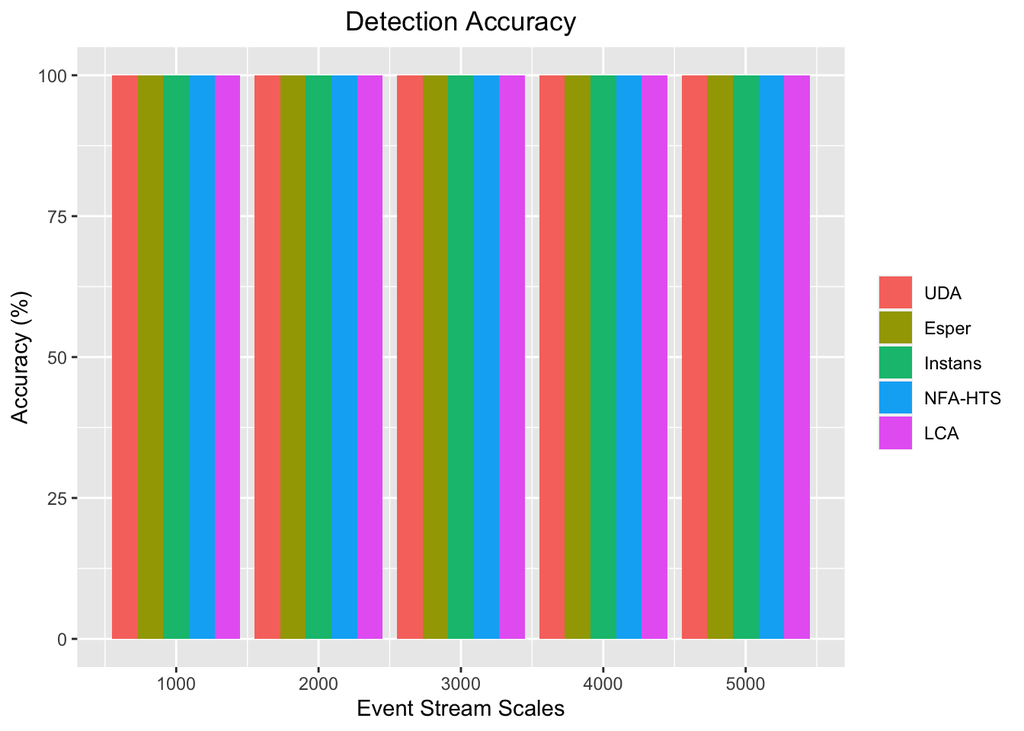

```r
library(ggplot2)
library(dplyr)
figure_accuracy <- ggplot(accuracy_melt, aes(x=scales, y=value, fill=variable)) +
  geom_bar(stat = "identity", position = position_dodge()) +
  labs(y = "Accuracy (%)", x="Event Stream Scales") + ggtitle("Detection Accuracy")+
  theme(plot.title = element_text(hjust = 0.5), legend.title = element_blank())

print(figure_accuracy)
```